# Momentum Investing & Machine Learning

## Background and Introduction

The concept of stocks and the stock market has been around for hundereds of years, but the years of brokers yelling on the market exchange floor have been replaced by computers. Algorithmic trading nowadays consists of close to 70% of all trades made worldwide. In the modern age machines run arbitration algorithms that operate on the margins of nanoseconds. Companies invest millions annually into technology and talent to gain the ever diminishing edge on their competition.

(Read more here : https://www.wired.com/2012/02/high-speed-trading/)

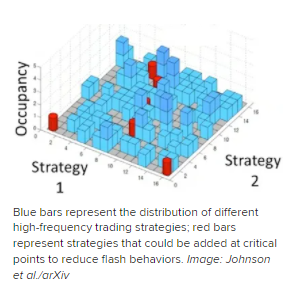

### Momentum

The stock market is very complicated, and as a byproduct, it is not perfectly efficient. One of these inefficiencies is momentum and will be the focus of this project. Momentum in the stock market is similar to physical momentum and describes the phenomenon that a stock that performs well and very well is likely to continue doing so, and a stock that is performing poorly will continue to do the same, and to the degree it was performing previously as well. It is important to note that these observations really only hold in the short term. There is variance as to how short this length is, but for the sake of this project we will focus on the performance of past 2 weeks. For a more technical explaination of momentum and some of its causing factors take a look at the Investopedia article linked below.

(Read more here: https://www.investopedia.com/trading/introduction-to-momentum-trading/).

### Investing with Machine Learning

We will perform some exploratory data analysis to determine the best momentum related features to use to predict stock prices. We will be using a stock that tracks the S&P 500. There is an exchange traded fund (ETF) called the "SPDR S&P 500 ETF Trust" with ticker symbol SPY. This project will attempt to profitably trade SPY shares. For information on what an ETF is and the S&P 500 is please refer to the link below.

(Read more here: What is an ETF? - https://www.investopedia.com/terms/e/etf.asp)

(Read more here: What is the S&P 500? - https://www.investopedia.com/terms/s/sp500.asp)

# Data Collection

```python
import pandas as pd
import numpy as np
import matplotlib.pyplot as plt
import tensorflow as tf
from pandas.plotting import scatter_matrix
from sklearn.model_selection import train_test_split
from sklearn.model_selection import cross_validate
from tensorflow import keras
```

```python
# data taken from https://www.kaggle.com/borismarjanovic/price-volume-data-for-all-us-stocks-etfs
spydf =  pd.read_csv("archive/ETFs/spy.us.txt")
spydf
```

|  | Date | Open | High | Low | Close | Volume | OpenInt |
| --- | --- | --- | --- | --- | --- | --- | --- |
| 0 | 2005-02-25 | 104.77 | 106.00 | 104.68 | 105.79 | 70221808 | 0 |
| 1 | 2005-02-28 | 105.55 | 105.68 | 104.56 | 105.08 | 79695344 | 0 |
| 2 | 2005-03-01 | 105.22 | 105.87 | 105.22 | 105.62 | 54607412 | 0 |
| 3 | 2005-03-02 | 105.21 | 106.22 | 105.10 | 105.57 | 73733090 | 0 |
| 4 | 2005-03-03 | 105.99 | 106.20 | 105.15 | 105.61 | 71286823 | 0 |
| ... | ... | ... | ... | ... | ... | ... | ... |
| 3196 | 2017-11-06 | 258.30 | 259.00 | 258.22 | 258.85 | 49529148 | 0 |
| 3197 | 2017-11-07 | 258.97 | 259.35 | 258.11 | 258.67 | 57218448 | 0 |
| 3198 | 2017-11-08 | 258.47 | 259.22 | 258.15 | 259.11 | 50277699 | 0 |
| 3199 | 2017-11-09 | 257.73 | 258.39 | 256.36 | 258.17 | 94537282 | 0 |
| 3200 | 2017-11-10 | 257.73 | 258.21 | 257.37 | 258.09 | 59862364 | 0 |

3201 rows × 7 columns

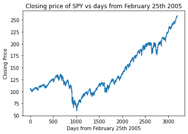

```python
plt.title("Closing price of SPY vs days from February 25th 2005")
plt.plot(spydf["Close"])  #Note the large drop during the 2008 recession!
plt.xlabel("Days from February 25th 2005")
plt.ylabel("Closing Price")
```

### Wait, do we need a strategy at all?

What some of you may have noticed already is that this graph is already trending upwards rather significantly. This is not a coincedence. The data stops at around the end of 2017 where SPY was trading just below 260, as of writing this, SPY is trading around 470. An ETF with high volume like SPY is a great long-term investment. You can safely expect long term returns of 7-10% annually, but this is only in very long-term cases. You may be down over a month or even a couple of years, but the S&P 500 will never continue to not grow. While this might make it a great option for 401k's, it is not possible to make high returns in the short term without some sort of risk/strategy. This is where we will use the short term nature of momentum to our advantage.

Our metric for sucess shouldn't be whether we were profitable, but whether we were more profitable than buying, then doing nothing.

# Data Processing

### Moving Average Convergence Divergence (MACD)

This is a popular techincal indicator for momentum. It uses two different exponentially weighted moving averages. Information on how it is calculated can be found here:

https://www.investopedia.com/terms/m/macd.asp

```python
k = spydf['Close'].ewm(span=12, adjust=False, min_periods=12).mean() # this is the 12 day exponential weighted mean
d = spydf['Close'].ewm(span=26, adjust=False, min_periods=26).mean() # this is the 26 day exponential weighted mean
macd = k-d # This is the actual formula for MACD
macd_s = macd.ewm(span=9, adjust=False, min_periods=9).mean() # Get the 9-Day EMA of the MACD for the Trigger line
macd_h = macd - macd_s # Calculate the difference between the MACD - Trigger for the Convergence/Divergence value

# Add all of our new values for the MACD to the dataframe
spydf['macd'] = spydf.index.map(macd)
spydf['macd_h'] = spydf.index.map(macd_h)
spydf['macd_s'] = spydf.index.map(macd_s)
```

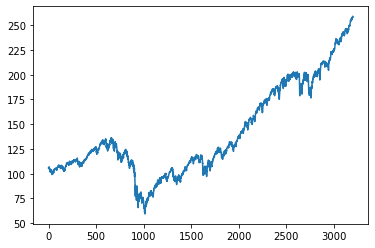

```python
plt.plot(spydf["Close"])
```

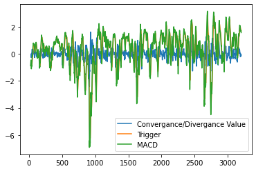

```python
plt.plot(spydf["macd_h"], label = "Convergance/Divergance Value")
plt.plot(spydf["macd_s"], label = "Trigger")
plt.plot(spydf["macd"], label = "MACD")
plt.legend()
```

### Relative Strength Index (RSI)

Relative Strength Index or RSI is another momentum indicator

For a great article filled with cool history check out: https://www.alpharithms.com/relative-strength-index-rsi-in-python-470209/

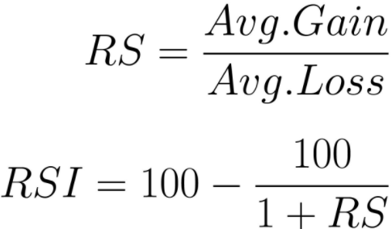

```python
spydf["diff"] = spydf["Close"].diff(1)  #calculates the price change from previous day
spydf["gain"] = spydf["diff"].clip(lower = 0)  #picks the positive values
spydf["loss"] = spydf["diff"].clip(upper = 0).abs() #picks the absolute value of the negative values
spydf["avg_gain"] = spydf["gain"].rolling(14).mean() #14 day avg of gains
spydf["avg_loss"] = spydf["loss"].rolling(14).mean() #14 day avg of loss
spydf["rs"] = spydf["avg_gain"]/spydf["avg_loss"]
spydf['rsi'] = 100 - (100 / (1.0 + spydf['rs'])) #calcultes RSI using RS in the formula above
```

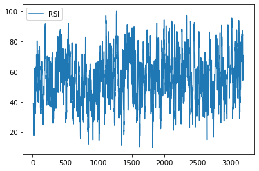

```python
plt.plot(spydf["rsi"], label = "RSI")
plt.legend()
```

```python
spydf
```

|  | Date | Open | High | Low | Close | Volume | OpenInt | macd | macd_h | macd_s | diff | gain | loss | avg_gain | avg_loss | rs | rsi |
| --- | --- | --- | --- | --- | --- | --- | --- | --- | --- | --- | --- | --- | --- | --- | --- | --- | --- |
| 0 | 2005-02-25 | 104.77 | 106.00 | 104.68 | 105.79 | 70221808 | 0 | NaN | NaN | NaN | NaN | NaN | NaN | NaN | NaN | NaN | NaN |
| 1 | 2005-02-28 | 105.55 | 105.68 | 104.56 | 105.08 | 79695344 | 0 | NaN | NaN | NaN | -0.71 | 0.00 | 0.71 | NaN | NaN | NaN | NaN |
| 2 | 2005-03-01 | 105.22 | 105.87 | 105.22 | 105.62 | 54607412 | 0 | NaN | NaN | NaN | 0.54 | 0.54 | 0.00 | NaN | NaN | NaN | NaN |
| 3 | 2005-03-02 | 105.21 | 106.22 | 105.10 | 105.57 | 73733090 | 0 | NaN | NaN | NaN | -0.05 | 0.00 | 0.05 | NaN | NaN | NaN | NaN |
| 4 | 2005-03-03 | 105.99 | 106.20 | 105.15 | 105.61 | 71286823 | 0 | NaN | NaN | NaN | 0.04 | 0.04 | 0.00 | NaN | NaN | NaN | NaN |
| ... | ... | ... | ... | ... | ... | ... | ... | ... | ... | ... | ... | ... | ... | ... | ... | ... | ... |
| 3196 | 2017-11-06 | 258.30 | 259.00 | 258.22 | 258.85 | 49529148 | 0 | 1.744350 | -0.018796 | 1.763146 | 0.40 | 0.40 | 0.00 | 0.472143 | 0.230714 | 2.046440 | 67.174797 |
| 3197 | 2017-11-07 | 258.97 | 259.35 | 258.11 | 258.67 | 57218448 | 0 | 1.739594 | -0.018841 | 1.758436 | -0.18 | 0.00 | 0.18 | 0.454286 | 0.243571 | 1.865103 | 65.097236 |
| 3198 | 2017-11-08 | 258.47 | 259.22 | 258.15 | 259.11 | 50277699 | 0 | 1.751144 | -0.005833 | 1.756977 | 0.44 | 0.44 | 0.00 | 0.480714 | 0.243571 | 1.973607 | 66.370809 |
| 3199 | 2017-11-09 | 257.73 | 258.39 | 256.36 | 258.17 | 94537282 | 0 | 1.665251 | -0.073381 | 1.738632 | -0.94 | 0.00 | 0.94 | 0.386429 | 0.310714 | 1.243678 | 55.430328 |
| 3200 | 2017-11-10 | 257.73 | 258.21 | 257.37 | 258.09 | 59862364 | 0 | 1.572597 | -0.132828 | 1.705425 | -0.08 | 0.00 | 0.08 | 0.386429 | 0.245000 | 1.577259 | 61.199095 |

3201 rows × 17 columns

### Average Directional Index (ADX)

ADX is a technical indicator that shows how strong a certain trend is. For more information and detailed code examples on how to calculate ADX, refer to this website: https://medium.com/codex/algorithmic-trading-with-average-directional-index-in-python-2b5a20ecf06a

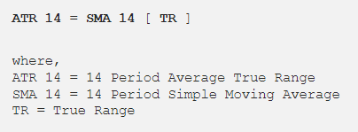

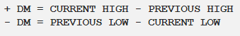

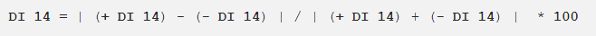

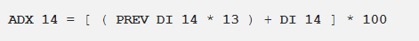

```python
plus_dm = spydf["High"].diff() #This block calculates plusdm and minusdm, the signed difference between highs and lows of a day
minus_dm = spydf["Low"].diff()
plus_dm[plus_dm < 0] = 0
minus_dm[minus_dm > 0] = 0

tr1 = pd.DataFrame(spydf["High"] - spydf["Low"]) #three different ranges to find true range from
tr2 = pd.DataFrame(abs(spydf["High"] - spydf["Close"].shift(1)))
tr3 = pd.DataFrame(abs(spydf["Low"] - spydf["Close"].shift(1)))
tr = pd.concat([tr1, tr2, tr3], axis = 1, join = 'inner').max(axis = 1)#true range taking max of the three different differences
atr = tr.rolling(14).mean() # average true range calcuated using formula above

spydf["plus_di"] = 100 * (plus_dm.ewm(alpha = 1/14).mean() / atr)
spydf["minus_di"] = abs(100 * (minus_dm.ewm(alpha = 1/14).mean() / atr))
#DI 14 using penultimate formula
dx = (abs(spydf["plus_di"] - spydf["minus_di"]) / abs(spydf["plus_di"] + spydf["minus_di"])) * 100
adx = ((dx.shift(1) * (14 - 1)) + dx) / 14 #calcuating adx using last formula
spydf["adx_smooth"] = adx.ewm(alpha = 1/14).mean() #smoothing adx with a 14 day exponentially weighted average
```

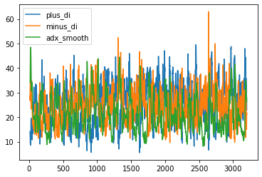

```python
plt.plot(spydf["plus_di"], label = "plus_di")
plt.plot(spydf["minus_di"], label = "minus_di")
plt.plot(spydf["adx_smooth"], label = "adx_smooth")
plt.legend()
```

```python
spydf
```

|  | Date | Open | High | Low | Close | Volume | OpenInt | macd | macd_h | macd_s | diff | gain | loss | avg_gain | avg_loss | rs | rsi | plus_di | minus_di | adx_smooth |
| --- | --- | --- | --- | --- | --- | --- | --- | --- | --- | --- | --- | --- | --- | --- | --- | --- | --- | --- | --- | --- |
| 0 | 2005-02-25 | 104.77 | 106.00 | 104.68 | 105.79 | 70221808 | 0 | NaN | NaN | NaN | NaN | NaN | NaN | NaN | NaN | NaN | NaN | NaN | NaN | NaN |
| 1 | 2005-02-28 | 105.55 | 105.68 | 104.56 | 105.08 | 79695344 | 0 | NaN | NaN | NaN | -0.71 | 0.00 | 0.71 | NaN | NaN | NaN | NaN | NaN | NaN | NaN |
| 2 | 2005-03-01 | 105.22 | 105.87 | 105.22 | 105.62 | 54607412 | 0 | NaN | NaN | NaN | 0.54 | 0.54 | 0.00 | NaN | NaN | NaN | NaN | NaN | NaN | NaN |
| 3 | 2005-03-02 | 105.21 | 106.22 | 105.10 | 105.57 | 73733090 | 0 | NaN | NaN | NaN | -0.05 | 0.00 | 0.05 | NaN | NaN | NaN | NaN | NaN | NaN | NaN |
| 4 | 2005-03-03 | 105.99 | 106.20 | 105.15 | 105.61 | 71286823 | 0 | NaN | NaN | NaN | 0.04 | 0.04 | 0.00 | NaN | NaN | NaN | NaN | NaN | NaN | NaN |
| ... | ... | ... | ... | ... | ... | ... | ... | ... | ... | ... | ... | ... | ... | ... | ... | ... | ... | ... | ... | ... |
| 3196 | 2017-11-06 | 258.30 | 259.00 | 258.22 | 258.85 | 49529148 | 0 | 1.744350 | -0.018796 | 1.763146 | 0.40 | 0.40 | 0.00 | 0.472143 | 0.230714 | 2.046440 | 67.174797 | 30.607057 | 17.156432 | 27.707877 |
| 3197 | 2017-11-07 | 258.97 | 259.35 | 258.11 | 258.67 | 57218448 | 0 | 1.739594 | -0.018841 | 1.758436 | -0.18 | 0.00 | 0.18 | 0.454286 | 0.243571 | 1.865103 | 65.097236 | 29.125739 | 15.872712 | 27.746823 |
| 3198 | 2017-11-08 | 258.47 | 259.22 | 258.15 | 259.11 | 50277699 | 0 | 1.751144 | -0.005833 | 1.756977 | 0.44 | 0.44 | 0.00 | 0.480714 | 0.243571 | 1.973607 | 66.370809 | 27.641490 | 15.063838 | 27.868635 |
| 3199 | 2017-11-09 | 257.73 | 258.39 | 256.36 | 258.17 | 94537282 | 0 | 1.665251 | -0.073381 | 1.738632 | -0.94 | 0.00 | 0.94 | 0.386429 | 0.310714 | 1.243678 | 55.430328 | 23.870401 | 21.958700 | 27.852762 |
| 3200 | 2017-11-10 | 257.73 | 258.21 | 257.37 | 258.09 | 59862364 | 0 | 1.572597 | -0.132828 | 1.705425 | -0.08 | 0.00 | 0.08 | 0.386429 | 0.245000 | 1.577259 | 61.199095 | 22.909945 | 21.075164 | 26.161234 |

3201 rows × 20 columns

### Stochastic Oscillator (SO)

A stochastic oscillator is a momentum indicator that responds to changes in the closing price of a security in comparison to a range of its prices over a certain period of time.

Obligatory Investopedia: https://www.investopedia.com/terms/s/stochasticoscillator.asp

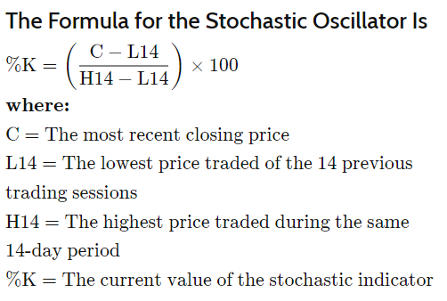

```python
spydf["rolling-min"] = spydf["Low"].rolling(14).min() #L14, 14 day low
spydf["rolling-max"] = spydf["High"].rolling(14).max() #H14, 14 day high
spydf["%K"] = (spydf["Close"] - spydf["rolling-min"])*100/(spydf["rolling-max"] - spydf["rolling-min"]) #%K using formula above
spydf["%D"] = spydf["%K"].rolling(3).mean() #%D is a 3 day rolling mean of %K
```

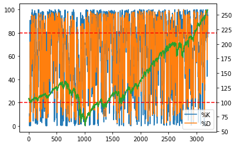

```python
ax=spydf[["%K","%D"]].plot()
spydf["Close"].plot(ax = ax, secondary_y=True)
ax.axhline(20, linestyle = "--", color = "r")
ax.axhline(80, linestyle = "--", color = "r")
```

### Momentum itself

There is actually a statistic itself called momentum, it is calcualted as such:

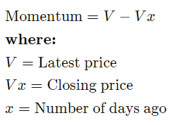

check out https://www.investopedia.com/articles/technical/081501.asp for more info

```python
def subtract(x): #custom function to apply using rolling function of pandas
    return x.iloc[-1] - x.iloc[0]

spydf["momentum"] = spydf['Close'].rolling(window=14).apply(subtract)# subtract
```

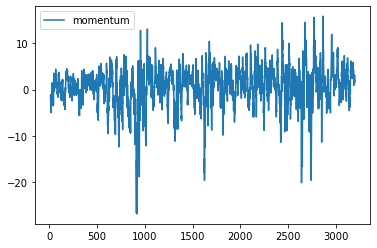

```python
plt.plot(spydf["momentum"], label = "momentum")
plt.legend()
```

```python
spydf
```

|  | Date | Open | High | Low | Close | Volume | OpenInt | macd | macd_h | macd_s | ... | rs | rsi | plus_di | minus_di | adx_smooth | rolling-min | rolling-max | %K | %D | momentum |
| --- | --- | --- | --- | --- | --- | --- | --- | --- | --- | --- | --- | --- | --- | --- | --- | --- | --- | --- | --- | --- | --- |
| 0 | 2005-02-25 | 104.77 | 106.00 | 104.68 | 105.79 | 70221808 | 0 | NaN | NaN | NaN | ... | NaN | NaN | NaN | NaN | NaN | NaN | NaN | NaN | NaN | NaN |
| 1 | 2005-02-28 | 105.55 | 105.68 | 104.56 | 105.08 | 79695344 | 0 | NaN | NaN | NaN | ... | NaN | NaN | NaN | NaN | NaN | NaN | NaN | NaN | NaN | NaN |
| 2 | 2005-03-01 | 105.22 | 105.87 | 105.22 | 105.62 | 54607412 | 0 | NaN | NaN | NaN | ... | NaN | NaN | NaN | NaN | NaN | NaN | NaN | NaN | NaN | NaN |
| 3 | 2005-03-02 | 105.21 | 106.22 | 105.10 | 105.57 | 73733090 | 0 | NaN | NaN | NaN | ... | NaN | NaN | NaN | NaN | NaN | NaN | NaN | NaN | NaN | NaN |
| 4 | 2005-03-03 | 105.99 | 106.20 | 105.15 | 105.61 | 71286823 | 0 | NaN | NaN | NaN | ... | NaN | NaN | NaN | NaN | NaN | NaN | NaN | NaN | NaN | NaN |
| ... | ... | ... | ... | ... | ... | ... | ... | ... | ... | ... | ... | ... | ... | ... | ... | ... | ... | ... | ... | ... | ... |
| 3196 | 2017-11-06 | 258.30 | 259.00 | 258.22 | 258.85 | 49529148 | 0 | 1.744350 | -0.018796 | 1.763146 | ... | 2.046440 | 67.174797 | 30.607057 | 17.156432 | 27.707877 | 254.0 | 259.00 | 97.000000 | 92.309088 | 3.13 |
| 3197 | 2017-11-07 | 258.97 | 259.35 | 258.11 | 258.67 | 57218448 | 0 | 1.739594 | -0.018841 | 1.758436 | ... | 1.865103 | 65.097236 | 29.125739 | 15.872712 | 27.746823 | 254.0 | 259.35 | 87.289720 | 94.392870 | 2.88 |
| 3198 | 2017-11-08 | 258.47 | 259.22 | 258.15 | 259.11 | 50277699 | 0 | 1.751144 | -0.005833 | 1.756977 | ... | 1.973607 | 66.370809 | 27.641490 | 15.063838 | 27.868635 | 254.0 | 259.35 | 95.514019 | 93.267913 | 2.00 |
| 3199 | 2017-11-09 | 257.73 | 258.39 | 256.36 | 258.17 | 94537282 | 0 | 1.665251 | -0.073381 | 1.738632 | ... | 1.243678 | 55.430328 | 23.870401 | 21.958700 | 27.852762 | 254.0 | 259.35 | 77.943925 | 86.915888 | 2.06 |
| 3200 | 2017-11-10 | 257.73 | 258.21 | 257.37 | 258.09 | 59862364 | 0 | 1.572597 | -0.132828 | 1.705425 | ... | 1.577259 | 61.199095 | 22.909945 | 21.075164 | 26.161234 | 254.0 | 259.35 | 76.448598 | 83.302181 | 1.53 |

3201 rows × 25 columns

### Summary of Indicators:

So far we have calculated 4 different momentum indicators along with momentum itself: MACD, RSI, ADX, SO, and momentum. Most of these indicators like MACD, ADX, and SO also have auxilliary indicators like the trigger for MACD, the plus_di and minus_di for ADX, and %D for SO. These auxilliary indicators act as a benchmark so we have some sense of relative performance regarding our indicator. We will be exploring these realtionships more in the next section.

# Exploratory Data Analysis & Visualization

Now that we have so many different ways to track the same thing, we are now going to delve deeper to see if we can see some relationships between the different indicators so that we can decide which type of machine learning model and which features would be the best to use to predict stock prices.

If you take a look at the articles attached with each indicator, you will note that most of them mention the short-comings and inter/intra-relationships between different indicators. We will see if we can observe the same trends that the articles do.

As you can see from the graphs we have drawn so far, all of them look rather noisy without too much pattern, this sort of makes sense as most of these indicators are oscillators and momentum is known to have reverting properties. Hopefully we will be able to see trends generalize better if we start looking at the data from a less macro perspective.

### Correlation intra-statistics

Let's begin our EDA by first examining the correlation between our different momentum statistics. Lets begin by first trying to see any relationships between the inidividual indicators and their auxilliary variables.

### MACD

```
array([[<AxesSubplot:xlabel='macd', ylabel='macd'>,
        <AxesSubplot:xlabel='macd_h', ylabel='macd'>,
        <AxesSubplot:xlabel='macd_s', ylabel='macd'>,
        <AxesSubplot:xlabel='momentum', ylabel='macd'>],
       [<AxesSubplot:xlabel='macd', ylabel='macd_h'>,
        <AxesSubplot:xlabel='macd_h', ylabel='macd_h'>,
        <AxesSubplot:xlabel='macd_s', ylabel='macd_h'>,
        <AxesSubplot:xlabel='momentum', ylabel='macd_h'>],
       [<AxesSubplot:xlabel='macd', ylabel='macd_s'>,
        <AxesSubplot:xlabel='macd_h', ylabel='macd_s'>,
        <AxesSubplot:xlabel='macd_s', ylabel='macd_s'>,
        <AxesSubplot:xlabel='momentum', ylabel='macd_s'>],
       [<AxesSubplot:xlabel='macd', ylabel='momentum'>,
        <AxesSubplot:xlabel='macd_h', ylabel='momentum'>,
        <AxesSubplot:xlabel='macd_s', ylabel='momentum'>,
        <AxesSubplot:xlabel='momentum', ylabel='momentum'>]], dtype=object)
```

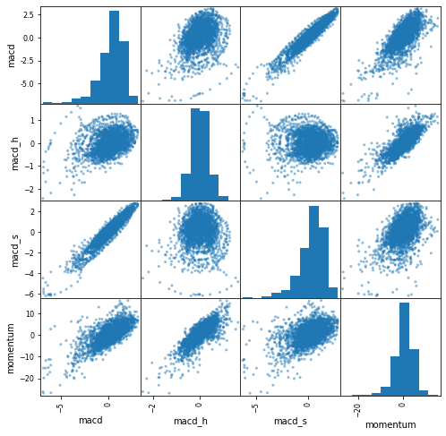

```python
statsdf = pd.concat([spydf["macd"], spydf["macd_h"], spydf["macd_s"], spydf["momentum"]], axis = 1)
scatter_matrix(statsdf, figsize = (8,8))
```

### ADX

Here we see that ADX and its auxilliary variables are more noisy than MACD. This doesn't mean there aren't trends however, it looks like minus_di and plus_di seem to have a negativly correlated linear relationship with each other. minus_di also seems to have a nosier negatively correlated linear relationship with adx, with plus_di and adx being too noisy to claim that they are linear in good faith. This makes me more inclined to include all three statistics when training a model, due to the lack of intuitive generalization. Oddly enough, plus_di and minus_di seem to have a stronger correlation with momentum than adx by initial glance. Considering this, it would be good to include it in our model.

```
array([[<AxesSubplot:xlabel='adx_smooth', ylabel='adx_smooth'>,
        <AxesSubplot:xlabel='plus_di', ylabel='adx_smooth'>,
        <AxesSubplot:xlabel='minus_di', ylabel='adx_smooth'>,
        <AxesSubplot:xlabel='momentum', ylabel='adx_smooth'>],
       [<AxesSubplot:xlabel='adx_smooth', ylabel='plus_di'>,
        <AxesSubplot:xlabel='plus_di', ylabel='plus_di'>,
        <AxesSubplot:xlabel='minus_di', ylabel='plus_di'>,
        <AxesSubplot:xlabel='momentum', ylabel='plus_di'>],
       [<AxesSubplot:xlabel='adx_smooth', ylabel='minus_di'>,
        <AxesSubplot:xlabel='plus_di', ylabel='minus_di'>,
        <AxesSubplot:xlabel='minus_di', ylabel='minus_di'>,
        <AxesSubplot:xlabel='momentum', ylabel='minus_di'>],
       [<AxesSubplot:xlabel='adx_smooth', ylabel='momentum'>,
        <AxesSubplot:xlabel='plus_di', ylabel='momentum'>,
        <AxesSubplot:xlabel='minus_di', ylabel='momentum'>,
        <AxesSubplot:xlabel='momentum', ylabel='momentum'>]], dtype=object)
```

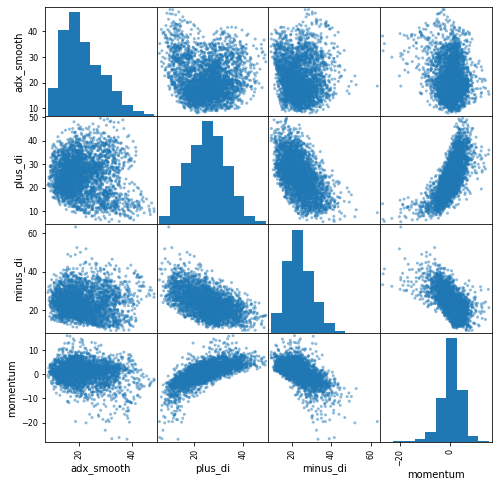

```python
statsdf = pd.concat([spydf["adx_smooth"], spydf["plus_di"], spydf["minus_di"], spydf["momentum"]], axis = 1)
scatter_matrix(statsdf, figsize = (8,8))
```

### OC

As to be expected average_min and average_max are very correlated over time. It is a bit more suprising to see the much more complicated relationships between the other variables. %D and %K have a noisy linear correlation which makes sense as %D is a small windowed moving average of %K. I think the relationship is noisy enough include both variables in whatever model we use. I am much more likely to remove either average_min or average_max, but considering there is no formula declaring their linearity, their natural linearity of their difference might be something of value to the model. The OC calculation itself seems far too noisy.

```
array([[<AxesSubplot:xlabel='rolling-min', ylabel='rolling-min'>,
        <AxesSubplot:xlabel='rolling-max', ylabel='rolling-min'>,
        <AxesSubplot:xlabel='%D', ylabel='rolling-min'>,
        <AxesSubplot:xlabel='%K', ylabel='rolling-min'>],
       [<AxesSubplot:xlabel='rolling-min', ylabel='rolling-max'>,
        <AxesSubplot:xlabel='rolling-max', ylabel='rolling-max'>,
        <AxesSubplot:xlabel='%D', ylabel='rolling-max'>,
        <AxesSubplot:xlabel='%K', ylabel='rolling-max'>],
       [<AxesSubplot:xlabel='rolling-min', ylabel='%D'>,
        <AxesSubplot:xlabel='rolling-max', ylabel='%D'>,
        <AxesSubplot:xlabel='%D', ylabel='%D'>,
        <AxesSubplot:xlabel='%K', ylabel='%D'>],
       [<AxesSubplot:xlabel='rolling-min', ylabel='%K'>,
        <AxesSubplot:xlabel='rolling-max', ylabel='%K'>,
        <AxesSubplot:xlabel='%D', ylabel='%K'>,
        <AxesSubplot:xlabel='%K', ylabel='%K'>]], dtype=object)
```

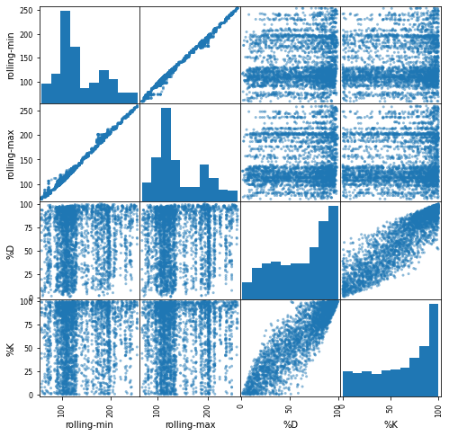

```python
statsdf = pd.concat([spydf["rolling-min"],spydf["rolling-max"], spydf["%D"], spydf["%K"]], axis = 1)
scatter_matrix(statsdf, figsize = (8,8))
```

### Plotting during high correlance time frames

Our previous plots for our momentum indicators were not very descriptive. Let us pick a smaller time frame of clearly postively or negatively trending data and see if our indicators can more clearly be used to describe trends.

### Momentum indicators during negative trends

https://en.wikipedia.org/wiki/Financial_crisis_of_2007%E2%80%932008

Let's examine what our momentum indactors say about this time period.

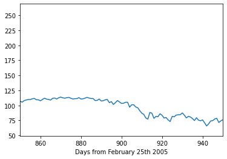

```python
plt.plot(spydf["Close"])
plt.xlim([850,950])
plt.xlabel("Days from February 25th 2005")
```

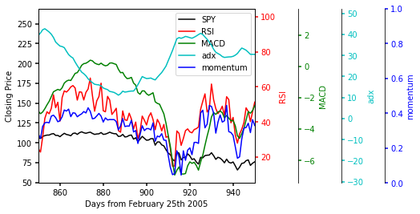

```python
fig, ax = plt.subplots()
fig.subplots_adjust(right=0.75)

twin1 = ax.twinx()
twin2 = ax.twinx()
twin3 = ax.twinx()
twin4 = ax.twinx()

# Offset the right spine of twin2.  The ticks and label have already been
# placed on the right by twinx above.
twin2.spines['right'].set_position(("axes", 1.2))
twin3.spines['right'].set_position(("axes", 1.4))
twin4.spines['right'].set_position(("axes", 1.6))

p1, = ax.plot(spydf["Close"], "k-", label="SPY")
p2, = twin1.plot(spydf["rsi"], "r-", label="RSI")
p3, = twin2.plot(spydf["macd"], "g-", label="MACD")
p4, = twin3.plot(spydf["adx_smooth"], "c-", label="adx")
p5, = twin3.plot(spydf["momentum"], "b-", label="momentum")

ax.set_xlim(850, 950)

ax.set_xlabel("Days from February 25th 2005")
ax.set_ylabel("Closing Price")
twin1.set_ylabel("RSI")
twin2.set_ylabel("MACD")
twin3.set_ylabel("adx")
twin4.set_ylabel("momentum")

ax.yaxis.label.set_color(p1.get_color())
twin1.yaxis.label.set_color(p2.get_color())
twin2.yaxis.label.set_color(p3.get_color())
twin3.yaxis.label.set_color(p4.get_color())
twin4.yaxis.label.set_color(p5.get_color())

tkw = dict(size=4, width=1.5)
ax.tick_params(axis='y', colors=p1.get_color(), **tkw)
twin1.tick_params(axis='y', colors=p2.get_color(), **tkw)
twin2.tick_params(axis='y', colors=p3.get_color(), **tkw)
twin3.tick_params(axis='y', colors=p4.get_color(), **tkw)
twin4.tick_params(axis='y', colors=p5.get_color(), **tkw)
ax.tick_params(axis='x', **tkw)

ax.legend(handles=[p1, p2, p3, p4, p5])
```

[output not shown]

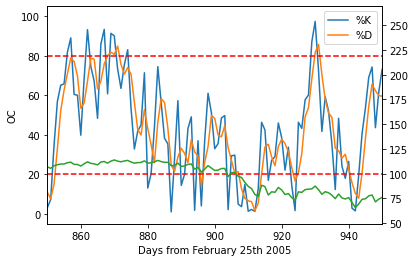

```python
ax=spydf[["%K","%D"]].plot()
spydf["Close"].plot(ax = ax, secondary_y=True)
ax.axhline(20, linestyle = "--", color = "r") #these lines are common signal values for SO
ax.axhline(80, linestyle = "--", color = "r")
ax.set_xlabel("Days from February 25th 2005")
ax.set_ylabel("OC")
ax.set_xlim([850, 950])
```

### Analysis of indicators during crisis

In the graphs above we see that RSI and MACD both approximate momentum rather well. ADX doesn't do this, but thats ok because it isn't supposed to, its just an indicator of change in general. What we see is that OC itself is far noisier than the other indicators (hence why it was put on another graph). If we look closely we can see that if we smoothed OC, it actually begins to resemble the other indicator functions. We will do one last analysis to determine weather it is worth keeping.

### One last analysis

```
array([[<AxesSubplot:xlabel='Close', ylabel='Close'>,
        <AxesSubplot:xlabel='macd', ylabel='Close'>,
        <AxesSubplot:xlabel='rsi', ylabel='Close'>,
        <AxesSubplot:xlabel='adx_smooth', ylabel='Close'>,
        <AxesSubplot:xlabel='%K', ylabel='Close'>,
        <AxesSubplot:xlabel='%D', ylabel='Close'>,
        <AxesSubplot:xlabel='plus_di', ylabel='Close'>,
        <AxesSubplot:xlabel='minus_di', ylabel='Close'>,
        <AxesSubplot:xlabel='momentum', ylabel='Close'>],
       [<AxesSubplot:xlabel='Close', ylabel='macd'>,
        <AxesSubplot:xlabel='macd', ylabel='macd'>,
        <AxesSubplot:xlabel='rsi', ylabel='macd'>,
        <AxesSubplot:xlabel='adx_smooth', ylabel='macd'>,
        <AxesSubplot:xlabel='%K', ylabel='macd'>,
        <AxesSubplot:xlabel='%D', ylabel='macd'>,
        <AxesSubplot:xlabel='plus_di', ylabel='macd'>,
        <AxesSubplot:xlabel='minus_di', ylabel='macd'>,
        <AxesSubplot:xlabel='momentum', ylabel='macd'>],
       [<AxesSubplot:xlabel='Close', ylabel='rsi'>,
        <AxesSubplot:xlabel='macd', ylabel='rsi'>,
        <AxesSubplot:xlabel='rsi', ylabel='rsi'>,
        <AxesSubplot:xlabel='adx_smooth', ylabel='rsi'>,
        <AxesSubplot:xlabel='%K', ylabel='rsi'>,
        <AxesSubplot:xlabel='%D', ylabel='rsi'>,
        <AxesSubplot:xlabel='plus_di', ylabel='rsi'>,
        <AxesSubplot:xlabel='minus_di', ylabel='rsi'>,
        <AxesSubplot:xlabel='momentum', ylabel='rsi'>],
       [<AxesSubplot:xlabel='Close', ylabel='adx_smooth'>,
        <AxesSubplot:xlabel='macd', ylabel='adx_smooth'>,
        <AxesSubplot:xlabel='rsi', ylabel='adx_smooth'>,
        <AxesSubplot:xlabel='adx_smooth', ylabel='adx_smooth'>,
        <AxesSubplot:xlabel='%K', ylabel='adx_smooth'>,
        <AxesSubplot:xlabel='%D', ylabel='adx_smooth'>,
        <AxesSubplot:xlabel='plus_di', ylabel='adx_smooth'>,
        <AxesSubplot:xlabel='minus_di', ylabel='adx_smooth'>,
        <AxesSubplot:xlabel='momentum', ylabel='adx_smooth'>],
       [<AxesSubplot:xlabel='Close', ylabel='%K'>,
        <AxesSubplot:xlabel='macd', ylabel='%K'>,
        <AxesSubplot:xlabel='rsi', ylabel='%K'>,
        <AxesSubplot:xlabel='adx_smooth', ylabel='%K'>,
```

[output cut: 26 more lines]

```
        <AxesSubplot:xlabel='adx_smooth', ylabel='minus_di'>,
        <AxesSubplot:xlabel='%K', ylabel='minus_di'>,
        <AxesSubplot:xlabel='%D', ylabel='minus_di'>,
        <AxesSubplot:xlabel='plus_di', ylabel='minus_di'>,
        <AxesSubplot:xlabel='minus_di', ylabel='minus_di'>,
        <AxesSubplot:xlabel='momentum', ylabel='minus_di'>],
       [<AxesSubplot:xlabel='Close', ylabel='momentum'>,
        <AxesSubplot:xlabel='macd', ylabel='momentum'>,
        <AxesSubplot:xlabel='rsi', ylabel='momentum'>,
        <AxesSubplot:xlabel='adx_smooth', ylabel='momentum'>,
        <AxesSubplot:xlabel='%K', ylabel='momentum'>,
        <AxesSubplot:xlabel='%D', ylabel='momentum'>,
        <AxesSubplot:xlabel='plus_di', ylabel='momentum'>,
        <AxesSubplot:xlabel='minus_di', ylabel='momentum'>,
        <AxesSubplot:xlabel='momentum', ylabel='momentum'>]], dtype=object)
```

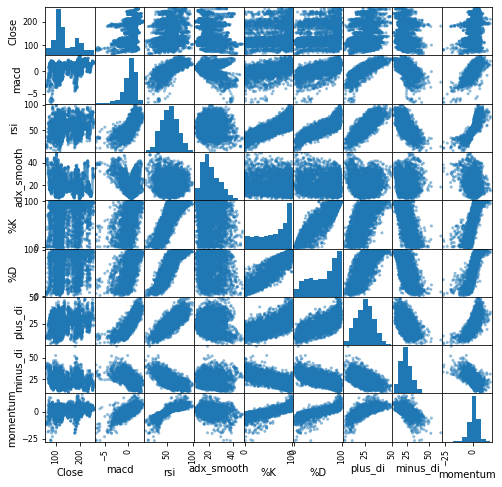

```python
statsdf = pd.concat([spydf["Close"], spydf["macd"], spydf["rsi"], spydf["adx_smooth"], spydf["%K"], spydf["%D"], spydf["plus_di"], spydf["minus_di"], spydf["momentum"]], axis = 1)
scatter_matrix(statsdf, figsize = (8,8))
```

Here we see that each of these indicators are actually providing useful information one way or another. %K and %D are providing essentailly the same information, so we will just use %D in its place. In addition, while minus_di and plus_di seem to be providing the same (but inverted) correlative information with regards to momemtum, we see that the extent of the correlation is different. As a result, we will keep both in case some generalization can be made from some mathematical expression of the two of them.

### OUR FINAL FEATURES!!!

1. Close
2. macd
3. rsi
4. adx_smooth
5. plus_di
6. minus_di
7. %D
8. momentum

# Model: Analysis, hypothesis testing, & ML

### Choice of Model

The model we will use to predict these stock prices will be a recurrent neural network, more specifically one with long short-term memory cells. For information on LSTM-RNNs please read this gentle introduction to the topic.

https://machinelearningmastery.com/gentle-introduction-long-short-term-memory-networks-experts/

In short, LSTM-RNNs are able to generalize to and predict time series data extremely well. The entire jist of our objective here is to learn features over a set period of time so this model structure lends itself very well to our desired task.

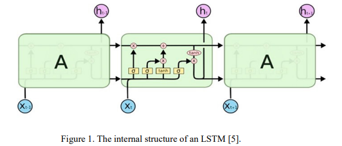

### Null Hypothesis

If momentum had no effect on the stock market, we could say that the prediction ability of predicting profitability would essentially be random. There would be a 50% chance that the next day would have a higher closing price and a 50% chance that the next day would have a lower closing price.

We said before that we don't just want to predict whether the next day will be profitable or not, but to forecast a little bit into the future to make sure that our momentum investing methodology will work well better than just holding the stock in the long run. If we can use our model to do this, we can reject the null.

In this case we will use ~ 3 weeks worth of data, 20 days, to estimate the value of the next 4.

### Caveats

We need to be careful with how we feed our model into our RNN. The entire point of using an RNN is that it can generalize over sequences. We need to make sure that the input itself is a timeseries sequnce, this is a common mistake that novice users make.

Another issue is how we standardize our inputs and outputs. It is very clear that our inputs and outputs all use rather different scales. It doesn't make sense to standardize the entire dataset at once. Stocks in general tend to have very large overall trends like we saw in our first plot of SPY standardizing the entire dataset at once will have a meaningless mean and standard deviation with respect to the output, as we are looking for short term trends. We will account for this by **standardizing each input and output individually**, using the mean and std for each x,y pair (20 + 4 = 24) data points. This will drastically increase computation time, but will only have to be done once when training once for testing, and once for each validation point (to de-normalize it to get a stock price).

### Let's begin!

First lets create a new df with only the values we need so we don't waste any computation while normalizing. We will then drop the first few rows as they will no values for these rolling indicators

```python
mldf = spydf.filter(["Close", "macd", "rsi", "adx_smooth", "plus_di", "minus_di", "%D", "momentum"], axis=1)
mldf = mldf.dropna()
mldf
```

|  | Close | macd | rsi | adx_smooth | plus_di | minus_di | %D | momentum |
| --- | --- | --- | --- | --- | --- | --- | --- | --- |
| 25 | 102.48 | -0.875044 | 29.435484 | 46.424263 | 12.227959 | 28.621735 | 26.892437 | -2.17 |
| 26 | 102.97 | -0.797766 | 38.068182 | 45.600634 | 15.200855 | 27.256094 | 34.286176 | -0.80 |
| 27 | 103.32 | -0.700208 | 46.543779 | 43.604676 | 18.344742 | 25.698930 | 49.218459 | -0.67 |
| 28 | 103.87 | -0.571920 | 49.122807 | 40.695627 | 18.767582 | 23.324562 | 70.657021 | 0.61 |
| 29 | 102.80 | -0.550248 | 46.796657 | 37.655970 | 17.405319 | 23.668291 | 72.246749 | -0.09 |
| ... | ... | ... | ... | ... | ... | ... | ... | ... |
| 3196 | 258.85 | 1.744350 | 67.174797 | 27.707877 | 30.607057 | 17.156432 | 92.309088 | 3.13 |
| 3197 | 258.67 | 1.739594 | 65.097236 | 27.746823 | 29.125739 | 15.872712 | 94.392870 | 2.88 |
| 3198 | 259.11 | 1.751144 | 66.370809 | 27.868635 | 27.641490 | 15.063838 | 93.267913 | 2.00 |
| 3199 | 258.17 | 1.665251 | 55.430328 | 27.852762 | 23.870401 | 21.958700 | 86.915888 | 2.06 |
| 3200 | 258.09 | 1.572597 | 61.199095 | 26.161234 | 22.909945 | 21.075164 | 83.302181 | 1.53 |

3176 rows × 8 columns

```python
totalx = []
totaly = []

for x in range(25, 3155, 5): #we are using 3155 as it the max value that is a multiple of 5 that allows for complete sets of
                              # inputs and outputs.
    s = mldf.iloc[x:x+24]
    s = (s-s.mean())/s.std() #this standardizes the df by column for us
    trax = s.iloc[0:20]
    tray = s.iloc[20:24].filter(["Close"], axis = 1)
    totalx.append(trax)
    totaly.append(tray)
```

```python
from tensorflow.keras.layers import LSTM, Dropout, Dense
```

```python
totalx = np.array(totalx, dtype=object)
totaly = np.array(totaly, dtype=object)
print(totalx.shape, totaly.shape)
```

```
(626, 20, 8) (626, 4, 1)
```

```python
trainx = totalx[:-100] #we are taking the last 100 time sequences for our test data
trainy = totaly[:-100]
testx = totalx[-100:]
testy = totaly[-100:]
trainy = trainy.reshape((len(trainy),len(trainy[0])))
testy = testy.reshape((len(testy),len(testy[0])))
print(trainx.shape, trainy.shape, testx.shape, testy.shape)
```

```
(526, 20, 8) (526, 4) (100, 20, 8) (100, 4)
```

```python
model = tf.keras.Sequential()
#Adding the first LSTM layer and some Dropout regularisation
model.add(LSTM(units = 50, return_sequences = True, input_shape = (trainx.shape[1], trainx.shape[2])))
model.add(Dropout(0.2))
# Adding a second LSTM layer and some Dropout regularisation
model.add(LSTM(units = 50, return_sequences = True))
model.add(Dropout(0.2))
# Adding a third LSTM layer and some Dropout regularisation
model.add(LSTM(units = 50, return_sequences = True))
model.add(Dropout(0.2))
# Adding a fourth LSTM layer and some Dropout regularisation
model.add(LSTM(units = 50))
model.add(Dropout(0.2))
# Adding the output layer, make sure the activation is linear (default) so we can make unbounded predictions
model.add(Dense(units = 4))

# Compiling the RNN
model.compile(optimizer = 'adam', loss = 'mean_squared_error')

# Fitting the RNN to the Training set
model.fit(trainx, trainy, epochs = 100, batch_size = 32)
```

[output not shown]

```
<tensorflow.python.keras.callbacks.History at 0x1d7cc9dc1c8>
```

```python
test_acc = model.evaluate(testx,  testy, verbose=1)
print('Test accuracy:', test_acc)
```

```
Test accuracy: 0.3346118974685669
```

### Performance analysis

```python
predy = model.predict(testx)
```

```python
#this tests how many days that the model classifies as closing positive vs closing negative vs closing negative relative to
#average of past 3 weeks.
correct = 0
total = 0
for x in range(len(predy)):
    for y in range(len(predy[0])):
        if np.sign(predy[x][y]) == np.sign(testy[x][y]):
            correct += 1
        total +=1
print("accuracy:", correct/total)
```

```
accuracy: 0.905
```

Here we see that our model classifies whether each individual predicted date will be higher or lower than the mean of the past 3 weeks with 90% accuracy. This means that our model has clearly learned to generalize to the sequence. This in and of itself may not be too impressive, as SPY is usually not too volatile, and it would make sense if the most recent days did not stray too far from the most recent values in the seqeunce. Regardless, the fact that the model was able to predict this with such high accuracy means that **it learned something with the features we gave it**. We were also able to **reject our null hypothesis** as our features were able to use predict momentum with over 90% accuracy, which is significantly different from what you would expect from a no-correlation value of 50%.

```python
a =[] # This cell is just to determine where to begin the for loop in the following cell
for x in range(25, 3155, 5):
    a.append(x)
a[-100]
```

```
2655
```

```python
count = 0 #in this cell, we are de-normalizing the predicted output to plot it against the true values
date = []
unnorm = []
for x in range(2655, 3155, 5): #reasons for these bounds explained above
    s = mldf.iloc[x:x+24]
    stock = predy[count] * s["Close"].std() + s["Close"].mean() #standardization formula in reverse
    count += 1
    for k in range(4): #loop through each prediction vector
        date.append(x+20+24+k)
        unnorm.append(stock[k])
```

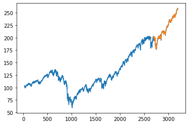

```python
plt.plot(mldf["Close"])
plt.plot(date, unnorm)
```

```
(2500.0, 3200.0)
```

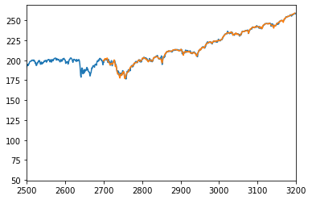

```python
plt.plot(mldf["Close"])
plt.plot(date, unnorm)
plt.xlim(2500, 3200)
```

```
(2700.0, 2850.0)
```

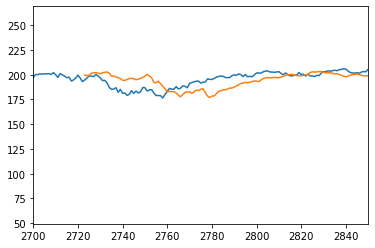

```python
date_shifted = [x + 24 for x in date]
plt.plot(mldf["Close"])
plt.plot(date_shifted, unnorm)
plt.xlim(2700, 2850)
```

# Insight, Policy Decision, and Improvements to be Made

A large reason for the predictive power of the model is the short amount of prediction days compared to input days 4 to 20. I would like to experiment with both of these values to see the effect of increasing and decreasing both of them to observe their effects on accuracy.

One last thing that I would want to observe in the future is trying more combinations of features to see how they effect the model. We tried with our exploratory data analysis to determine an optimal choice of sorts, but it would be interesting to perhaps try just momentum indicators without price, or perhaps nothing but closing price as a timeseries and letting the RNN learn momentum features on its own.

Overall, I hope this notebook gave you some insight into investing with machine learning and momentum trading. Thanks for reading!